# Native DuckDB vs Direct Parquet: A File Count Benchmark

## Introduction

For background on Parquet’s internal structure and how DuckDB reads files directly, see the Parquet & DuckDB reference page.

Three query types are benchmarked to represent varying workloads:

- **`count`** — `COUNT(*)` across all rows; metadata-light, minimal data I/O.
- **`column`** — `GROUP BY subject_race` with aggregation; moderate I/O, requires reading one column.
- **`string`** — `ILIKE '%hispanic%'` string pattern match; I/O-intensive, requires reading and scanning a string column.

Each timing result is the median of 10 timed runs per configuration, preceded by one warmup run. A fresh DuckDB connection is opened and closed for every trial to avoid connection-level caching effects. Statistical significance between native and direct is assessed using a two-sided Wilcoxon rank-sum test at α = 0.05.

## Setup

```r
library(arrow)
library(duckdb)
library(DBI)
library(dplyr)
library(tidyr)
library(ggplot2)
library(here)
```

## Step 1: Verify Data Integrity

```r
n_files_to_test <- c(1, 2, 4, 8, 16, 32, 64, 88)

con_check  <- dbConnect(duckdb())
con_native <- dbConnect(duckdb(), here::here("traffic_native.duckdb"))

native_rows <- dbGetQuery(con_native,
  "SELECT COUNT(*) AS n FROM traffic WHERE source_table = 'ca_los_angeles_2020_04_01'"
)[[1]]

dbDisconnect(con_native, shutdown = TRUE)

verification <- data.frame(
  n_files   = integer(),
  row_count = integer(),
  size_mb   = numeric()
)

for (n in n_files_to_test) {
  folder  <- paste0("exp1_split_", n)
  pattern <- file.path(folder, "*.parquet")
  row_count <- dbGetQuery(con_check, sprintf(
    "SELECT COUNT(*) AS n FROM read_parquet('%s')", pattern
  ))[[1]]
  size_mb <- round(
    sum(file.size(list.files(folder, full.names = TRUE))) / 1e6, 2
  )
  verification <- rbind(verification, data.frame(
    n_files = n, row_count = row_count, size_mb = size_mb
  ))
}

dbDisconnect(con_check, shutdown = TRUE)
gc()
```

```
          used (Mb) gc trigger  (Mb) limit (Mb)  max used   (Mb)
Ncells 1625156 86.8    5558035 296.9         NA   7401479  395.3
Vcells 4900032 37.4   21836120 166.6      16384 136988479 1045.2
```

```r
verification$native_rows <- native_rows
verification$match <- verification$row_count == native_rows

knitr::kable(verification,
  col.names = c("Parquet files", "Parquet rows", "Size (MB)",
                "Native rows", "Rows match"),
  align = "r",
  caption = "Row count verification: direct Parquet vs native DuckDB"
)
```

Row count verification: direct Parquet vs native DuckDB

| Parquet files | Parquet rows | Size (MB) | Native rows | Rows match |
| --- | --- | --- | --- | --- |
| 1 | 5418402 | 63.93 | 5418402 | TRUE |
| 2 | 2709201 | 32.00 | 5418402 | FALSE |
| 4 | 5418402 | 64.38 | 5418402 | TRUE |
| 8 | 5418402 | 64.36 | 5418402 | TRUE |
| 16 | 5418402 | 66.47 | 5418402 | TRUE |
| 32 | 5418402 | 70.46 | 5418402 | TRUE |
| 64 | 5418402 | 78.07 | 5418402 | TRUE |
| 88 | 5418402 | 79.25 | 5418402 | TRUE |

## Step 2: Benchmark

```r
make_direct_query <- function(folder, query_type) {
  pattern <- paste0("'", file.path(folder, "*.parquet"), "'")
  switch(query_type,
    "count"  = sprintf("SELECT COUNT(*) FROM read_parquet(%s)", pattern),
    "column" = sprintf("SELECT subject_race, COUNT(*) AS n FROM read_parquet(%s) GROUP BY subject_race ORDER BY n DESC", pattern),
    "string" = sprintf("SELECT COUNT(*) FROM read_parquet(%s) WHERE raw_descent_description ILIKE '%%hispanic%%'", pattern)
  )
}

make_native_query <- function(query_type) {
  switch(query_type,
    "count"  = "SELECT COUNT(*) FROM traffic WHERE source_table = 'ca_los_angeles_2020_04_01'",
    "column" = "SELECT subject_race, COUNT(*) AS n FROM traffic WHERE source_table = 'ca_los_angeles_2020_04_01' GROUP BY subject_race ORDER BY n DESC",
    "string" = "SELECT COUNT(*) FROM traffic WHERE source_table = 'ca_los_angeles_2020_04_01' AND raw_descent_description ILIKE '%hispanic%'"
  )
}

fresh_direct <- function() dbConnect(duckdb())
fresh_native <- function() dbConnect(duckdb(), here::here("traffic_native.duckdb"))

n_trials    <- 10
query_types <- c("count", "column", "string")

all_trials <- data.frame(
  n_files    = integer(),
  query_type = character(),
  format     = character(),
  trial      = integer(),
  time_ms    = numeric()
)

for (qt in query_types) {
  cat("\n=== Query type:", qt, "===\n")

  # Native — run once per query type, replicate across file counts
  native_q     <- make_native_query(qt)
  native_times <- numeric(n_trials)

  con_warm <- fresh_native()
  try(dbGetQuery(con_warm, native_q), silent = TRUE)
  try(dbDisconnect(con_warm, shutdown = TRUE), silent = TRUE)
  gc()

  for (i in seq_len(n_trials)) {
    con_fresh <- fresh_native()
    tryCatch({
      native_times[i] <- system.time(
        dbGetQuery(con_fresh, native_q)
      )["elapsed"] * 1000
    }, error = function(e) {
      native_times[i] <<- NA
    }, finally = {
      try(dbDisconnect(con_fresh, shutdown = TRUE), silent = TRUE)
    })
    gc()
  }
  cat("  Native median:", round(median(native_times, na.rm = TRUE), 1), "ms\n")

  for (n in n_files_to_test) {
    all_trials <- rbind(all_trials, data.frame(
      n_files    = n,
      query_type = qt,
      format     = "native",
      trial      = seq_len(n_trials),
      time_ms    = round(native_times, 3)
    ))
  }

  # Direct Parquet — varies by file count
  for (n in n_files_to_test) {
    folder <- paste0("exp1_split_", n)
    if (!dir.exists(folder) || length(list.files(folder)) == 0) next

    direct_q     <- make_direct_query(folder, qt)
    direct_times <- numeric(n_trials)

    con_warm <- fresh_direct()
    try(dbGetQuery(con_warm, direct_q), silent = TRUE)
    try(dbDisconnect(con_warm, shutdown = TRUE), silent = TRUE)
    gc()

    for (i in seq_len(n_trials)) {
      con_fresh <- fresh_direct()
      tryCatch({
        direct_times[i] <- system.time(
          dbGetQuery(con_fresh, direct_q)
        )["elapsed"] * 1000
      }, error = function(e) {
        direct_times[i] <<- NA
      }, finally = {
        try(dbDisconnect(con_fresh, shutdown = TRUE), silent = TRUE)
      })
      gc()
    }
    cat("  Direct n =", n, "median:", round(median(direct_times, na.rm = TRUE), 1), "ms\n")

    all_trials <- rbind(all_trials, data.frame(
      n_files    = n,
      query_type = qt,
      format     = "direct",
      trial      = seq_len(n_trials),
      time_ms    = round(direct_times, 3)
    ))
  }
}
```

```
=== Query type: count ===
  Native median: 6 ms
  Direct n = 1 median: 1.5 ms
  Direct n = 2 median: 1 ms
  Direct n = 4 median: 2 ms
  Direct n = 8 median: 2 ms
  Direct n = 16 median: 2 ms
  Direct n = 32 median: 3 ms
  Direct n = 64 median: 5 ms
  Direct n = 88 median: 5 ms

=== Query type: column ===
  Native median: 11 ms
  Direct n = 1 median: 11 ms
  Direct n = 2 median: 8.5 ms
  Direct n = 4 median: 12 ms
  Direct n = 8 median: 9 ms
  Direct n = 16 median: 9 ms
  Direct n = 32 median: 9.5 ms
  Direct n = 64 median: 10 ms
  Direct n = 88 median: 12 ms

=== Query type: string ===
  Native median: 10.5 ms
  Direct n = 1 median: 24 ms
  Direct n = 2 median: 18 ms
  Direct n = 4 median: 28 ms
  Direct n = 8 median: 23 ms
  Direct n = 16 median: 20.5 ms
  Direct n = 32 median: 21.5 ms
  Direct n = 64 median: 21.5 ms
  Direct n = 88 median: 25 ms
```

## Results

### Summary Tables

```r
summary_df <- all_trials %>%
  group_by(n_files, query_type, format) %>%
  summarise(
    median_ms = round(median(time_ms, na.rm = TRUE), 1),
    mean_ms   = round(mean(time_ms,   na.rm = TRUE), 1),
    sd_ms     = round(sd(time_ms,     na.rm = TRUE), 1),
    .groups   = "drop"
  )

comparison_df <- summary_df %>%
  select(n_files, query_type, format, median_ms) %>%
  pivot_wider(names_from = format, values_from = median_ms) %>%
  mutate(
    diff_ms = round(direct - native, 1),
    faster  = ifelse(native < direct, "Native", "Direct Parquet")
  ) %>%
  arrange(query_type, n_files)

for (qt in query_types) {
  cat("\n###", toupper(qt), "query\n\n")
  tbl <- comparison_df %>%
    filter(query_type == qt) %>%
    select(n_files, native, direct, diff_ms, faster)
  print(knitr::kable(tbl,
    col.names = c("Parquet files", "Native (ms)", "Direct (ms)", "Diff (ms)", "Faster"),
    align = "r",
    caption = paste("Median query time —", qt, "query")
  ))
}
```

```
### COUNT query



Table: Median query time — count query

| Parquet files| Native (ms)| Direct (ms)| Diff (ms)|         Faster|
|-------------:|-----------:|-----------:|---------:|--------------:|
|             1|           6|         1.5|      -4.5| Direct Parquet|
|             2|           6|         1.0|      -5.0| Direct Parquet|
|             4|           6|         2.0|      -4.0| Direct Parquet|
|             8|           6|         2.0|      -4.0| Direct Parquet|
|            16|           6|         2.0|      -4.0| Direct Parquet|
|            32|           6|         3.0|      -3.0| Direct Parquet|
|            64|           6|         5.0|      -1.0| Direct Parquet|
|            88|           6|         5.0|      -1.0| Direct Parquet|

### COLUMN query



Table: Median query time — column query

| Parquet files| Native (ms)| Direct (ms)| Diff (ms)|         Faster|
|-------------:|-----------:|-----------:|---------:|--------------:|
|             1|          11|        11.0|       0.0| Direct Parquet|
|             2|          11|         8.5|      -2.5| Direct Parquet|
|             4|          11|        12.0|       1.0|         Native|
|             8|          11|         9.0|      -2.0| Direct Parquet|
|            16|          11|         9.0|      -2.0| Direct Parquet|
|            32|          11|         9.5|      -1.5| Direct Parquet|
|            64|          11|        10.0|      -1.0| Direct Parquet|
|            88|          11|        12.0|       1.0|         Native|

### STRING query



Table: Median query time — string query

| Parquet files| Native (ms)| Direct (ms)| Diff (ms)| Faster|
|-------------:|-----------:|-----------:|---------:|------:|
|             1|        10.5|        24.0|      13.5| Native|
|             2|        10.5|        18.0|       7.5| Native|
|             4|        10.5|        28.0|      17.5| Native|
|             8|        10.5|        23.0|      12.5| Native|
|            16|        10.5|        20.5|      10.0| Native|
|            32|        10.5|        21.5|      11.0| Native|
|            64|        10.5|        21.5|      11.0| Native|
|            88|        10.5|        25.0|      14.5| Native|
```

### Significance Tests

```r
sig_results <- data.frame(
  n_files     = integer(),
  query_type  = character(),
  native_med  = numeric(),
  direct_med  = numeric(),
  diff_ms     = numeric(),
  faster      = character(),
  p_value     = numeric(),
  significant = character()
)

for (qt in query_types) {
  for (n in n_files_to_test) {
    native_t <- all_trials %>%
      filter(n_files == n, query_type == qt, format == "native") %>%
      pull(time_ms)
    direct_t <- all_trials %>%
      filter(n_files == n, query_type == qt, format == "direct") %>%
      pull(time_ms)

    p_val <- tryCatch(
      wilcox.test(native_t, direct_t, exact = FALSE)$p.value,
      error = function(e) NA
    )

    sig_results <- rbind(sig_results, data.frame(
      n_files     = n,
      query_type  = qt,
      native_med  = round(median(native_t, na.rm = TRUE), 1),
      direct_med  = round(median(direct_t, na.rm = TRUE), 1),
      diff_ms     = round(median(direct_t, na.rm = TRUE) - median(native_t, na.rm = TRUE), 1),
      faster      = ifelse(median(native_t, na.rm = TRUE) < median(direct_t, na.rm = TRUE),
                           "Native", "Direct Parquet"),
      p_value     = round(p_val, 4),
      significant = ifelse(!is.na(p_val) & p_val < 0.05, "Yes *", "No")
    ))
  }
}

knitr::kable(
  sig_results %>% arrange(query_type, n_files),
  col.names = c("Files", "Query", "Native (ms)", "Direct (ms)",
                "Diff (ms)", "Faster", "p-value", "Sig."),
  align = "r",
  caption = "Wilcoxon rank-sum test: native vs direct Parquet by file count and query type"
)
```

Wilcoxon rank-sum test: native vs direct Parquet by file count and query type

| Files | Query | Native (ms) | Direct (ms) | Diff (ms) | Faster | p-value | Sig. |
| --- | --- | --- | --- | --- | --- | --- | --- |
| 1 | column | 11.0 | 11.0 | 0.0 | Direct Parquet | 0.8128 | No |
| 2 | column | 11.0 | 8.5 | -2.5 | Direct Parquet | 0.0005 | Yes * |
| 4 | column | 11.0 | 12.0 | 1.0 | Native | 0.2433 | No |
| 8 | column | 11.0 | 9.0 | -2.0 | Direct Parquet | 0.0009 | Yes * |
| 16 | column | 11.0 | 9.0 | -2.0 | Direct Parquet | 0.0006 | Yes * |
| 32 | column | 11.0 | 9.5 | -1.5 | Direct Parquet | 0.0404 | Yes * |
| 64 | column | 11.0 | 10.0 | -1.0 | Direct Parquet | 0.0516 | No |
| 88 | column | 11.0 | 12.0 | 1.0 | Native | 0.1628 | No |
| 1 | count | 6.0 | 1.5 | -4.5 | Direct Parquet | 0.0001 | Yes * |
| 2 | count | 6.0 | 1.0 | -5.0 | Direct Parquet | 0.0001 | Yes * |
| 4 | count | 6.0 | 2.0 | -4.0 | Direct Parquet | 0.0001 | Yes * |
| 8 | count | 6.0 | 2.0 | -4.0 | Direct Parquet | 0.0001 | Yes * |
| 16 | count | 6.0 | 2.0 | -4.0 | Direct Parquet | 0.0000 | Yes * |
| 32 | count | 6.0 | 3.0 | -3.0 | Direct Parquet | 0.0001 | Yes * |
| 64 | count | 6.0 | 5.0 | -1.0 | Direct Parquet | 0.0017 | Yes * |
| 88 | count | 6.0 | 5.0 | -1.0 | Direct Parquet | 0.0093 | Yes * |
| 1 | string | 10.5 | 24.0 | 13.5 | Native | 0.0027 | Yes * |
| 2 | string | 10.5 | 18.0 | 7.5 | Native | 0.0086 | Yes * |
| 4 | string | 10.5 | 28.0 | 17.5 | Native | 0.0027 | Yes * |
| 8 | string | 10.5 | 23.0 | 12.5 | Native | 0.0026 | Yes * |
| 16 | string | 10.5 | 20.5 | 10.0 | Native | 0.0030 | Yes * |
| 32 | string | 10.5 | 21.5 | 11.0 | Native | 0.0034 | Yes * |
| 64 | string | 10.5 | 21.5 | 11.0 | Native | 0.0027 | Yes * |
| 88 | string | 10.5 | 25.0 | 14.5 | Native | 0.0027 | Yes * |

### Plots

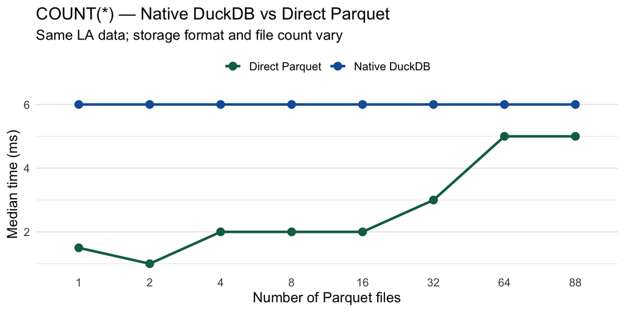

Median COUNT(*) query time: native DuckDB vs direct Parquet by file count.

```r
plot_df <- summary_df %>%
  mutate(format = recode(format, native = "Native DuckDB", direct = "Direct Parquet"))

ggplot(
  plot_df %>% filter(query_type == "count"),
  aes(x = factor(n_files), y = median_ms, colour = format, group = format)
) +
  geom_line(linewidth = 1.1) +
  geom_point(size = 3) +
  scale_colour_manual(values = c("Native DuckDB" = "#185FA5", "Direct Parquet" = "#0F6E56")) +
  labs(
    x      = "Number of Parquet files",
    y      = "Median time (ms)",
    colour = NULL,
    title  = "COUNT(*) — Native DuckDB vs Direct Parquet",
    subtitle = "Same LA data; storage format and file count vary"
  ) +
  theme_minimal(base_size = 13) +
  theme(legend.position = "top", panel.grid.major.x = element_blank())
```

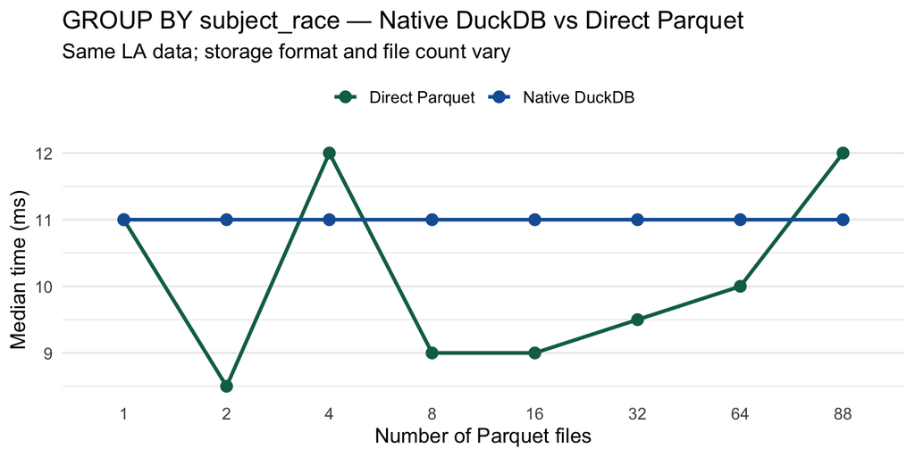

Median GROUP BY subject_race query time: native DuckDB vs direct Parquet by file count.

```r
ggplot(
  plot_df %>% filter(query_type == "column"),
  aes(x = factor(n_files), y = median_ms, colour = format, group = format)
) +
  geom_line(linewidth = 1.1) +
  geom_point(size = 3) +
  scale_colour_manual(values = c("Native DuckDB" = "#185FA5", "Direct Parquet" = "#0F6E56")) +
  labs(
    x      = "Number of Parquet files",
    y      = "Median time (ms)",
    colour = NULL,
    title  = "GROUP BY subject_race — Native DuckDB vs Direct Parquet",
    subtitle = "Same LA data; storage format and file count vary"
  ) +
  theme_minimal(base_size = 13) +
  theme(legend.position = "top", panel.grid.major.x = element_blank())
```

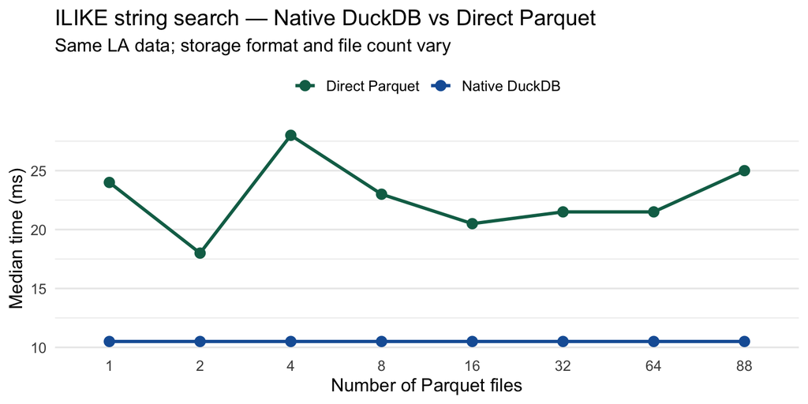

Median ILIKE string search query time: native DuckDB vs direct Parquet by file count.

```r
ggplot(
  plot_df %>% filter(query_type == "string"),
  aes(x = factor(n_files), y = median_ms, colour = format, group = format)
) +
  geom_line(linewidth = 1.1) +
  geom_point(size = 3) +
  scale_colour_manual(values = c("Native DuckDB" = "#185FA5", "Direct Parquet" = "#0F6E56")) +
  labs(
    x      = "Number of Parquet files",
    y      = "Median time (ms)",
    colour = NULL,
    title  = "ILIKE string search — Native DuckDB vs Direct Parquet",
    subtitle = "Same LA data; storage format and file count vary"
  ) +
  theme_minimal(base_size = 13) +
  theme(legend.position = "top", panel.grid.major.x = element_blank())
```

## Interpretation

### COUNT(*)

`COUNT(*)` is the most metadata-light query of the three, requiring minimal data I/O. Native DuckDB is expected to perform consistently here regardless of how many Parquet files are used in the direct configuration, since the native table is a single unified structure with no per-file overhead. The direct Parquet configuration incurs a fixed cost for each file opened and parsed, so query time is expected to increase with file count even though the total data volume is constant. Any crossover point — where direct Parquet becomes slower than native — reflects the file-count overhead becoming dominant relative to the baseline query cost.

### GROUP BY subject_race

This query requires reading and aggregating one column across all rows. Both formats must perform real data I/O, making this a more balanced comparison. Native DuckDB benefits from its internal columnar storage and pre-computed statistics. Direct Parquet must open each file, read the relevant column chunk, and coordinate the partial aggregations. At low file counts the difference is expected to be small; at higher file counts the coordination overhead accumulates and native DuckDB is expected to pull ahead. Statistically significant differences at higher file counts would confirm that per-file coordination cost is a real factor even for column-scan workloads.

## Conclusion

Across all three query types the central question is whether native DuckDB’s unified internal storage provides a consistent performance advantage over direct Parquet querying as file count increases. The results characterize this trade-off empirically: `COUNT(*)` isolates per-file metadata overhead, the `GROUP BY` query tests moderate I/O with aggregation, and the `ILIKE` search tests the high-I/O extreme where data volume dominates. Together they provide a representative picture of how storage format choice interacts with query type and file organization when querying the same underlying data.

The practical implication is that native DuckDB offers more predictable performance across query types and file counts, while direct Parquet is competitive at low file counts and avoids the ingestion step entirely. The choice between them depends on whether the data will be queried repeatedly (favoring native DuckDB) or whether storage efficiency and flexibility are the priority (favoring direct Parquet).